# Métodos Numéricos Aplicados a Finanças — Turma 2025

Aula 12

Prof. Frega PPGOLD/Universidade Federal do Paraná

27/05/2025

```r
library(magrittr)
.sgouttype = ifelse(!is.null(knitr::opts_knit$get("out.format")), "html", "text")
.stargazertype = .sgouttype
source("https://raw.githubusercontent.com/jrfrega/2025/refs/heads/main/mhist.R")
library(stargazer)
```

# 1 Chapter 15 Panel Data Models

```r
library(plm) # Panel Linear Models
library(tseries) # for `adf.test()`
library(dynlm) #for function `dynlm()`
library(vars) # for function `VAR()`
library(nlWaldTest) # for the `nlWaldtest()` function
library(lmtest) #for `coeftest()` and `bptest()`.
library(broom) #for `glance(`) and `tidy()`
library(PoEdata) #for PoE4 datasets
library(car) #for `hccm()` robust standard errors
library(sandwich)
library(knitr) #for `kable()`
library(forecast)
library(systemfit)
library(AER)
library(xtable)
```

$$\text{dados de corte}\\
y_i = \beta_0 + \sum_{j=1}^m \beta_j x_{ji} + \epsilon_i\\
\text{série temporal}\\
y_t = \beta_0 + \sum_{j=1}^k \beta_j x_{jt} + \epsilon_t\\
\text{dados em painel}\\
y_{it} = \beta_0 + \sum_{j=1}^k \beta_j x_{jit} + \epsilon_{it}\\$$

## 1.1 15.1 Organizing the Data as a Panel

Duas dimensões:

1. N = dimensão do corte
2. T = dimensão longitudinal

Se N>>T o painel é largo (*wide*)

Se N<<T o painel é longo (*long*)

Pode organizar como séries temporais empilhadas ou como unidades de análise empilhadas.

Mais comum é N séries temporais de tamanho T empilhadas.

```r
library(printr)
chars = c(1:3, "...", "N")
id = NULL
for (i in chars) {
  id = c(id, c(rep(i, 3), "...", i))
}
T = c(1:3, "...", "T")
T = rep(T, times = 5)
cbind(id, T) -> m
m[20, 2] = "T"
kable(m, table.attr = "") %>% kableExtra::kable_paper("striped", full_width = F, position = "left")
```

| id | T |
| --- | --- |
| 1 | 1 |
| 1 | 2 |
| 1 | 3 |
| … | … |
| 1 | T |
| 2 | 1 |
| 2 | 2 |
| 2 | 3 |
| … | … |
| 2 | T |
| 3 | 1 |
| 3 | 2 |
| 3 | 3 |
| … | … |
| 3 | T |
| … | 1 |
| … | 2 |
| … | 3 |
| … | … |
| … | T |
| N | 1 |
| N | 2 |
| N | 3 |
| … | … |
| N | T |

```r
library(xtable)
data("nls_panel", package="PoEdata")
nlspd <- pdata.frame(nls_panel, index=c("id", "year"))
smpl <- nlspd[nlspd$id %in% c(1,2),c(1:6, 14:15)]
smpl
```

| id | year | lwage | hours | age | educ | union | exper |
| --- | --- | --- | --- | --- | --- | --- | --- |
| 1 | 82 | 1.808289 | 38 | 30 | 12 | 1 | 7.666667 |
| 1 | 83 | 1.863417 | 38 | 31 | 12 | 1 | 8.583333 |
| 1 | 85 | 1.789367 | 38 | 33 | 12 | 1 | 10.179490 |
| 1 | 87 | 1.846530 | 40 | 35 | 12 | 1 | 12.179490 |
| 1 | 88 | 1.856449 | 40 | 37 | 12 | 1 | 13.621790 |
| 2 | 82 | 1.280933 | 48 | 36 | 17 | 0 | 7.576923 |
| 2 | 83 | 1.515855 | 43 | 37 | 17 | 0 | 8.384615 |
| 2 | 85 | 1.930170 | 35 | 39 | 17 | 0 | 10.384610 |
| 2 | 87 | 1.919034 | 42 | 41 | 17 | 1 | 12.038460 |
| 2 | 88 | 2.200974 | 42 | 43 | 17 | 1 | 13.211540 |

```r
#tbl <- xtable(smpl)
#kable(tbl, digits=4, align="c", caption="A data sample")
```

```r
pdim(nlspd[,])
```

```
## Balanced Panel: n = 716, T = 5, N = 3580
```

```r
pdim(nlspd[-c(1,2),])
```

```
## Unbalanced Panel: n = 716, T = 3-5, N = 3578
```

## 1.2 15.2 The Pooled Model

Pooled = *pooling*

```r
wage.pooled <- plm(lwage~educ+exper+I(exper^2)+tenure+I(tenure^2)+black+south+union, model="pooling", data=nlspd)
wage.pooled %>% summary
```

```
## Pooling Model
##
## Call:
## plm(formula = lwage ~ educ + exper + I(exper^2) + tenure + I(tenure^2) +
##     black + south + union, data = nlspd, model = "pooling")
##
## Balanced Panel: n = 716, T = 5, N = 3580
##
## Residuals:
##       Min.    1st Qu.     Median    3rd Qu.       Max.
## -1.6956994 -0.2331132 -0.0043786  0.2151676  2.5816751
##
## Coefficients:
##                Estimate  Std. Error t-value  Pr(>|t|)
## (Intercept)  0.47660008  0.05615585  8.4871 < 2.2e-16 ***
## educ         0.07144879  0.00268939 26.5669 < 2.2e-16 ***
## exper        0.05568504  0.00860716  6.4696 1.116e-10 ***
## I(exper^2)  -0.00114754  0.00036129 -3.1762 0.0015046 **
## tenure       0.01496002  0.00440728  3.3944 0.0006953 ***
## I(tenure^2) -0.00048604  0.00025770 -1.8860 0.0593697 .
## black       -0.11671387  0.01571590 -7.4265 1.387e-13 ***
## south       -0.10600256  0.01420083 -7.4645 1.045e-13 ***
## union        0.13224321  0.01496161  8.8388 < 2.2e-16 ***
## ---
## Signif. codes:  0 '***' 0.001 '**' 0.01 '*' 0.05 '.' 0.1 ' ' 1
##
## Total Sum of Squares:    772.56
## Residual Sum of Squares: 521.03
## R-Squared:      0.32559
## Adj. R-Squared: 0.32408
## F-statistic: 215.496 on 8 and 3571 DF, p-value: < 2.22e-16
```

```r
tbl <- tidy(coeftest(wage.pooled, vcov=vcovHC(wage.pooled,
                    type="HC0",cluster="group")))
tbl
```

| term | estimate | std.error | statistic | p.value |
| --- | --- | --- | --- | --- |
| (Intercept) | 0.4766001 | 0.0844094 | 5.646294 | 0.0000000 |
| educ | 0.0714488 | 0.0054895 | 13.015501 | 0.0000000 |
| exper | 0.0556850 | 0.0112896 | 4.932421 | 0.0000008 |
| I(exper^2) | -0.0011475 | 0.0004916 | -2.334396 | 0.0196301 |
| tenure | 0.0149600 | 0.0071102 | 2.104011 | 0.0354472 |
| I(tenure^2) | -0.0004860 | 0.0004095 | -1.186970 | 0.2353185 |
| black | -0.1167139 | 0.0280831 | -4.156021 | 0.0000331 |
| south | -0.1060026 | 0.0270124 | -3.924217 | 0.0000887 |
| union | 0.1322432 | 0.0270255 | 4.893274 | 0.0000010 |

## 1.3 15.3 The Fixed Effects

Fixos = *within*

```r
wage.within <- plm(lwage~educ+exper+I(exper^2)+tenure+I(tenure^2)+black+south+union, data=nlspd, model="within")
wage.within %>% summary
```

```
## Oneway (individual) effect Within Model
##
## Call:
## plm(formula = lwage ~ educ + exper + I(exper^2) + tenure + I(tenure^2) +
##     black + south + union, data = nlspd, model = "within")
##
## Balanced Panel: n = 716, T = 5, N = 3580
##
## Residuals:
##      Min.   1st Qu.    Median   3rd Qu.      Max.
## -1.173109 -0.068460  0.004701  0.078259  1.975920
##
## Coefficients:
##                Estimate  Std. Error t-value  Pr(>|t|)
## exper        0.04108314  0.00662001  6.2059 6.226e-10 ***
## I(exper^2)  -0.00040905  0.00027333 -1.4965    0.1346
## tenure       0.01390895  0.00327784  4.2433 2.272e-05 ***
## I(tenure^2) -0.00089623  0.00020586 -4.3536 1.386e-05 ***
## south       -0.01632239  0.03614900 -0.4515    0.6516
## union        0.06369724  0.01425380  4.4688 8.172e-06 ***
## ---
## Signif. codes:  0 '***' 0.001 '**' 0.01 '*' 0.05 '.' 0.1 ' ' 1
##
## Total Sum of Squares:    126.95
## Residual Sum of Squares: 108.8
## R-Squared:      0.14297
## Adj. R-Squared: -0.073232
## F-statistic: 79.4647 on 6 and 2858 DF, p-value: < 2.22e-16
```

Licença poética:

As variáveis que não variam ao longo do tempo para cada uma das unidades de análise não funcionam com modelos de efeitos fixos, ou seja, `educ` e `black` ficaram de fora do modelo.

### 1.3.1 Pergunta: o modelo `within` é melhor que o modelo `pooling`?

```r
# H0: as unidades de análise não apresentam significância
# pFtest(modelo a ser testado, modelo de referência)
pFtest(wage.within, wage.pooled)
```

```
##
##  F test for individual effects
##
## data:  lwage ~ educ + exper + I(exper^2) + tenure + I(tenure^2) + black +  ...
## F = 15.188, df1 = 713, df2 = 2858, p-value < 2.2e-16
## alternative hypothesis: significant effects
```

O p-value < 2.2e-16 do teste F rejeita a hipótese nula, levando-nos a crer que o modelo `within` é mais adequado que o modelo `pooling`.

## 1.4 15.4 The Random Effects Model

```r
# H0: não há efeitos significativos dos interceptos
wageReTest <- plmtest(wage.pooled, effect="individual")
wageReTest
```

```
##
##  Lagrange Multiplier Test - (Honda)
##
## data:  lwage ~ educ + exper + I(exper^2) + tenure + I(tenure^2) + black +  ...
## normal = 62.123, p-value < 2.2e-16
## alternative hypothesis: significant effects
```

O teste apresenta p-value < 2.2e-16 rejeitando H0 e favorecendo o modelo de efeitos aleatórios sobre o modelo `pooling`

`random.method` $\in$ {“swar” (Swamy-Arora — default), “amemiya”, “walhus”, or “nerlove”}

```r
wage.random <- plm(lwage~educ+exper+I(exper^2)+tenure+I(tenure^2)+black+south+union, data=nlspd,
                   random.method="swar",
                   model="random")
wage.random %>% summary
```

```
## Oneway (individual) effect Random Effect Model
##    (Swamy-Arora's transformation)
##
## Call:
## plm(formula = lwage ~ educ + exper + I(exper^2) + tenure + I(tenure^2) +
##     black + south + union, data = nlspd, model = "random", random.method = "swar")
##
## Balanced Panel: n = 716, T = 5, N = 3580
##
## Effects:
##                   var std.dev share
## idiosyncratic 0.03807 0.19511  0.26
## individual    0.10827 0.32905  0.74
## theta: 0.7437
##
## Residuals:
##       Min.    1st Qu.     Median    3rd Qu.       Max.
## -1.2578234 -0.0901908  0.0058526  0.0961519  2.1036453
##
## Coefficients:
##                Estimate  Std. Error z-value  Pr(>|z|)
## (Intercept)  0.53392954  0.07988279  6.6839 2.326e-11 ***
## educ         0.07325357  0.00533076 13.7417 < 2.2e-16 ***
## exper        0.04361696  0.00635758  6.8606 6.856e-12 ***
## I(exper^2)  -0.00056096  0.00026261 -2.1361 0.0326705 *
## tenure       0.01415413  0.00316656  4.4699 7.826e-06 ***
## I(tenure^2) -0.00075534  0.00019473 -3.8790 0.0001049 ***
## black       -0.11673659  0.03020871 -3.8643 0.0001114 ***
## south       -0.08181170  0.02241094 -3.6505 0.0002617 ***
## union        0.08023533  0.01321321  6.0724 1.260e-09 ***
## ---
## Signif. codes:  0 '***' 0.001 '**' 0.01 '*' 0.05 '.' 0.1 ' ' 1
##
## Total Sum of Squares:    169.36
## Residual Sum of Squares: 136.49
## R-Squared:      0.1941
## Adj. R-Squared: 0.1923
## Chisq: 860.081 on 8 DF, p-value: < 2.22e-16
```

Os coeficientes de intercepto individual estão distribuídos em torno da média estimada na regressão de efeitos aleatórios

$$\beta_{0i} = \bar{\beta_0} + u_i$$

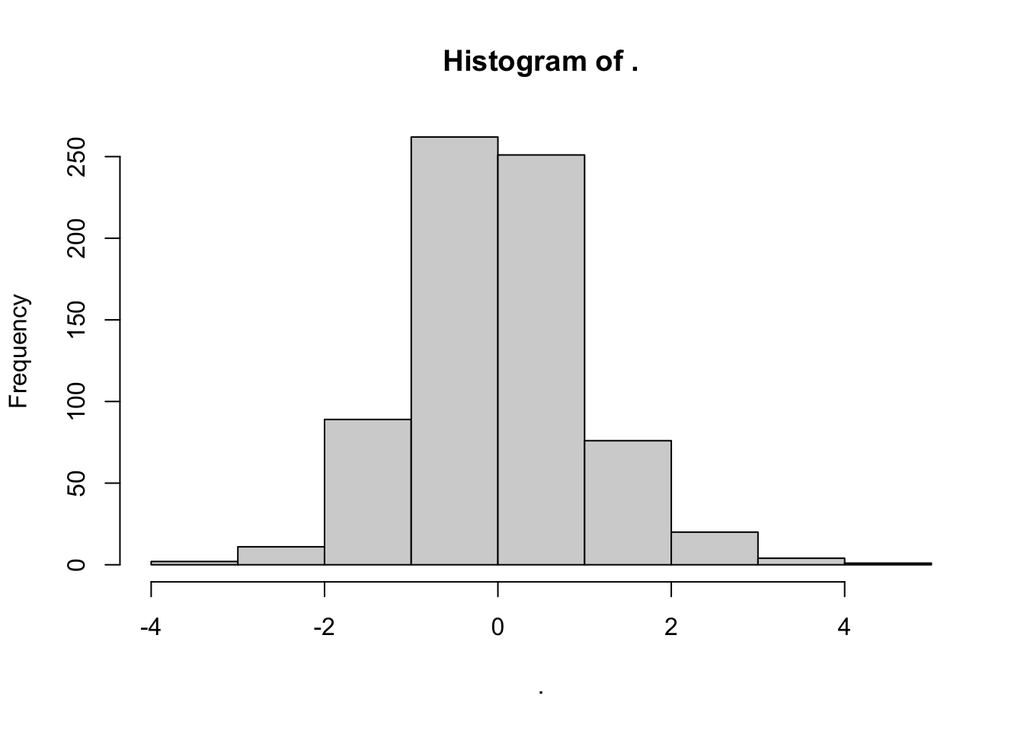

```r
ranef(wage.random) %>% round(12) %>% scale %>% hist
```

Agora o teste de consistência — Hausman

Porque consistência? Se houver endogeneidade no modelo, os coeficientes estarão enviesados e o modelo perderá consistência.

```r
# H0: ambos os modelos são consistentes
phtest(wage.within, wage.random)
```

```
##
##  Hausman Test
##
## data:  lwage ~ educ + exper + I(exper^2) + tenure + I(tenure^2) + black +  ...
## chisq = 20.725, df = 6, p-value = 0.002055
## alternative hypothesis: one model is inconsistent
```

```r
phtest(wage.pooled, wage.random)
```

```
##
##  Hausman Test
##
## data:  lwage ~ educ + exper + I(exper^2) + tenure + I(tenure^2) + black +  ...
## chisq = 67.269, df = 8, p-value = 1.714e-11
## alternative hypothesis: one model is inconsistent
```

O teste indica p-value = 0.002055 (na melhor hipótese), ou seja, um dos dois modelos é inconsistente. Como os modelos `within` e `pooling` são consistentes, o modelo inconsistente é o `random`.

Se pararmos nesta etapa, é necessário retornar ao modelo de efeitos fixos. Nesta situação perderemos as variáveis `educ` e `black`.

### 1.4.1 Estimador de Hausman-Taylor

```r
wage.HT <- plm(lwage~educ+exper+I(exper^2)+tenure+I(tenure^2)+black+south+union
               |
               exper+I(exper^2)+tenure+I(tenure^2)+union+black,
               data=nlspd, model="ht")
#wage.HT <- plm(lwage~educ+exper+I(exper^2)+tenure+I(tenure^2)+black+south+union
#               |
#               exper+I(exper^2)+tenure+I(tenure^2)+union+black,
#               data=nlspd, model="random", random.method = "ht", inst.method = "bms")
wage.HT %>% summary
```

```
## Oneway (individual) effect Hausman-Taylor Model
## (Hausman-Taylor estimator)
##
## Call:
## pht(formula = lwage ~ educ + exper + I(exper^2) + tenure + I(tenure^2) +
##     black + south + union | exper + I(exper^2) + tenure + I(tenure^2) +
##     union + black, data = nlspd)
##
## T.V. exo  : exper, I(exper^2), tenure, I(tenure^2), union
## T.V. endo : south
## T.I. exo  : black
## T.I. endo : educ
##
## Balanced Panel: n = 716, T = 5, N = 3580
##
## Effects:
##                   var std.dev share
## idiosyncratic 0.03799 0.19491 0.158
## individual    0.20238 0.44987 0.842
## theta: 0.8098
##
## Residuals:
##       Min.    1st Qu.     Median    3rd Qu.       Max.
## -1.1917740 -0.0885848  0.0048605  0.0964688  2.0898352
##
## Coefficients:
##                Estimate  Std. Error z-value  Pr(>|z|)
## (Intercept) -0.75077101  0.58623628 -1.2807 0.2003121
## educ         0.17050818  0.04446281  3.8348 0.0001256 ***
## exper        0.03990784  0.00647453  6.1638 7.101e-10 ***
## I(exper^2)  -0.00039134  0.00026763 -1.4622 0.1436812
## tenure       0.01432570  0.00315970  4.5339 5.791e-06 ***
## I(tenure^2) -0.00085256  0.00019740 -4.3189 1.568e-05 ***
## black       -0.03591345  0.06006813 -0.5979 0.5499209
## south       -0.03171219  0.03484738 -0.9100 0.3628064
## union        0.07196924  0.01345447  5.3491 8.839e-08 ***
## ---
## Signif. codes:  0 '***' 0.001 '**' 0.01 '*' 0.05 '.' 0.1 ' ' 1
##
## Total Sum of Squares:    772.56
## Residual Sum of Squares: 131.11
## Chisq: 609.256 on 8 DF, p-value: < 2.22e-16
```

```r
stargazer::stargazer(coeftest(wage.pooled), coeftest(wage.random), coeftest(wage.HT), type = "text")
```

```
##
## ========================================
##                 Dependent variable:
##            -----------------------------
##
##               (1)       (2)       (3)
## ----------------------------------------
## educ       0.071***  0.073***  0.171***
##             (0.003)   (0.005)   (0.044)
##
## exper      0.056***  0.044***  0.040***
##             (0.009)   (0.006)   (0.006)
##
## I(exper2)  -0.001*** -0.001**   -0.0004
##            (0.0004)  (0.0003)  (0.0003)
##
## tenure     0.015***  0.014***  0.014***
##             (0.004)   (0.003)   (0.003)
##
## I(tenure2) -0.0005*  -0.001*** -0.001***
##            (0.0003)  (0.0002)  (0.0002)
##
## black      -0.117*** -0.117***  -0.036
##             (0.016)   (0.030)   (0.060)
##
## south      -0.106*** -0.082***  -0.032
##             (0.014)   (0.022)   (0.035)
##
## union      0.132***  0.080***  0.072***
##             (0.015)   (0.013)   (0.013)
##
## Constant   0.477***  0.534***   -0.751
##             (0.056)   (0.080)   (0.586)
##
## ========================================
## ========================================
## Note:        *p<0.1; **p<0.05; ***p<0.01
```

## 1.5 15.5 Grunfeld’s Investment Example

```r
data("grunfeld2", package="PoEdata")
grun <- pdata.frame(grunfeld2, index=c("firm","year"))
grun
```

| inv | v | k | firm | year |
| --- | --- | --- | --- | --- |
| 33.10 | 1170.6 | 97.8 | 1 | 1935 |
| 45.00 | 2015.8 | 104.4 | 1 | 1936 |
| 77.20 | 2803.3 | 118.0 | 1 | 1937 |
| 44.60 | 2039.7 | 156.2 | 1 | 1938 |
| 48.10 | 2256.2 | 172.6 | 1 | 1939 |
| 74.40 | 2132.2 | 186.6 | 1 | 1940 |
| 113.00 | 1834.1 | 220.9 | 1 | 1941 |
| 91.90 | 1588.0 | 287.8 | 1 | 1942 |
| 61.30 | 1749.4 | 319.9 | 1 | 1943 |
| 56.80 | 1687.2 | 321.3 | 1 | 1944 |
| 93.60 | 2007.7 | 319.6 | 1 | 1945 |
| 159.90 | 2208.3 | 346.0 | 1 | 1946 |
| 147.20 | 1656.7 | 456.4 | 1 | 1947 |
| 146.30 | 1604.4 | 543.4 | 1 | 1948 |
| 98.30 | 1431.8 | 618.3 | 1 | 1949 |
| 93.50 | 1610.5 | 647.4 | 1 | 1950 |
| 135.20 | 1819.4 | 671.3 | 1 | 1951 |
| 157.30 | 2079.7 | 726.1 | 1 | 1952 |
| 179.50 | 2371.6 | 800.3 | 1 | 1953 |
| 189.60 | 2759.9 | 888.9 | 1 | 1954 |
| 12.93 | 191.5 | 1.8 | 2 | 1935 |
| 25.90 | 516.0 | 0.8 | 2 | 1936 |
| 35.05 | 729.0 | 7.4 | 2 | 1937 |
| 22.89 | 560.4 | 18.1 | 2 | 1938 |
| 18.84 | 519.9 | 23.5 | 2 | 1939 |
| 28.57 | 628.5 | 26.5 | 2 | 1940 |
| 48.51 | 537.1 | 36.2 | 2 | 1941 |
| 43.34 | 561.2 | 60.8 | 2 | 1942 |
| 37.02 | 617.2 | 84.4 | 2 | 1943 |
| 37.81 | 626.7 | 91.2 | 2 | 1944 |
| 39.27 | 737.2 | 92.4 | 2 | 1945 |
| 53.46 | 760.5 | 86.0 | 2 | 1946 |
| 55.56 | 581.4 | 111.1 | 2 | 1947 |
| 49.56 | 662.3 | 130.6 | 2 | 1948 |
| 32.04 | 583.8 | 141.8 | 2 | 1949 |
| 32.24 | 635.2 | 136.7 | 2 | 1950 |
| 54.38 | 723.8 | 129.7 | 2 | 1951 |
| 71.78 | 864.1 | 145.5 | 2 | 1952 |
| 90.08 | 1193.5 | 174.8 | 2 | 1953 |
| 68.60 | 1188.9 | 213.5 | 2 | 1954 |

```r
grun.pool <- plm(inv~v+k, model="pooling",data=grun)
grun.pool %>% summary
```

```
## Pooling Model
##
## Call:
## plm(formula = inv ~ v + k, data = grun, model = "pooling")
##
## Balanced Panel: n = 2, T = 20, N = 40
##
## Residuals:
##      Min.   1st Qu.    Median   3rd Qu.      Max.
## -41.79289 -11.45598  -0.43301   9.10769  58.79971
##
## Coefficients:
##               Estimate Std. Error t-value  Pr(>|t|)
## (Intercept) 17.8720011  7.0240806  2.5444   0.01525 *
## k            0.1435792  0.0186010  7.7189 3.194e-09 ***
## ---
## Signif. codes:  0 '***' 0.001 '**' 0.01 '*' 0.05 '.' 0.1 ' ' 1
##
## Total Sum of Squares:    87069
## Residual Sum of Squares: 16563
## R-Squared:      0.80977
## Adj. R-Squared: 0.79949
## F-statistic: 78.7517 on 2 and 37 DF, p-value: 4.6406e-14
```

```r
m = lm(inv~v+k, data=grun)
m %>% summary
```

```
##
## Call:
## lm(formula = inv ~ v + k, data = grun)
##
## Residuals:
##     Min      1Q  Median      3Q     Max
## -41.793 -11.456  -0.433   9.108  58.800
##
## Coefficients:
##              Estimate Std. Error t value Pr(>|t|)
## (Intercept) 17.872001   7.024081   2.544   0.0153 *
## k            0.143579   0.018601   7.719 3.19e-09 ***
## ---
## Signif. codes:  0 '***' 0.001 '**' 0.01 '*' 0.05 '.' 0.1 ' ' 1
##
## Residual standard error: 21.16 on 37 degrees of freedom
## Multiple R-squared:  0.8098, Adjusted R-squared:  0.7995
## F-statistic: 78.75 on 2 and 37 DF,  p-value: 4.641e-14
```

```r
SSE.pool <- sum(resid(grun.pool)^2)
sigma2.pool <- SSE.pool/(grun.pool$df.residual)
sigma2.pool
```

```
## [1] 447.6487
```

```r
grun.fe <- plm(inv~v*grun$firm+k*grun$firm, model="pooling",data=grun)
grun.fe %>% summary
```

```
## Pooling Model
##
## Call:
## plm(formula = inv ~ v * grun$firm + k * grun$firm, data = grun,
##     model = "pooling")
##
## Balanced Panel: n = 2, T = 20, N = 40
##
## Residuals:
##     Min.  1st Qu.   Median  3rd Qu.     Max.
## -37.5110 -10.5997  -2.8881   6.4841  58.7372
##
## Coefficients:
##               Estimate Std. Error t-value  Pr(>|t|)
## (Intercept)  -9.956306  23.626365 -0.4214    0.6761
## grun$firm2    9.446916  28.805351  0.3280    0.7450
## k             0.151694   0.019356  7.8369 4.016e-09 ***
## v:grun$firm2  0.026343   0.034353  0.7668    0.4485
## grun$firm2:k -0.059287   0.116946 -0.5070    0.6155
## ---
## Signif. codes:  0 '***' 0.001 '**' 0.01 '*' 0.05 '.' 0.1 ' ' 1
##
## Total Sum of Squares:    87069
## Residual Sum of Squares: 14990
## R-Squared:      0.82784
## Adj. R-Squared: 0.80252
## F-statistic: 32.6982 on 5 and 34 DF, p-value: 4.607e-12
```

```r
SSE.fe <- sum(resid(grun.fe)^2)
sigma2.fe <- SSE.fe/(grun.fe$df.residual)
sigma2.fe
```

```
## [1] 440.8771
```

```r
grun.within <- plm(inv~v+k, model="within",data=grun)
grun.within %>% summary
```

```
## Oneway (individual) effect Within Model
##
## Call:
## plm(formula = inv ~ v + k, data = grun, model = "within")
##
## Balanced Panel: n = 2, T = 20, N = 40
##
## Residuals:
##     Min.  1st Qu.   Median  3rd Qu.     Max.
## -36.3392 -10.3589  -2.1476   7.5634  57.8597
##
## Coefficients:
##   Estimate Std. Error t-value Pr(>|t|)
## k 0.151225   0.018608  8.1268 1.16e-09 ***
## ---
## Signif. codes:  0 '***' 0.001 '**' 0.01 '*' 0.05 '.' 0.1 ' ' 1
##
## Total Sum of Squares:    51787
## Residual Sum of Squares: 15250
## R-Squared:      0.70553
## Adj. R-Squared: 0.681
## F-statistic: 43.1276 on 2 and 36 DF, p-value: 2.771e-10
```

```r
pFtest(grun.within, grun.pool)
```

```
##
##  F test for individual effects
##
## data:  inv ~ v + k
## F = 3.1005, df1 = 1, df2 = 36, p-value = 0.08676
## alternative hypothesis: significant effects
```

Não há motivo para usar o modelo `within` no lugar do modelo `pooling`.

```r
grun1.pool <- plm(inv~v+k, model="pooling",
                 subset=grun$firm==1, data=grun)
grun1.pool %>% summary
```

```
## Pooling Model
##
## Call:
## plm(formula = inv ~ v + k, data = grun, subset = grun$firm ==
##     1, model = "pooling")
##
## Balanced Panel: n = 1, T = 20, N = 20
##
## Residuals:
##     Min.  1st Qu.   Median  3rd Qu.     Max.
## -37.5110 -23.3591  -3.9216   7.8241  58.7372
##
## Coefficients:
##              Estimate Std. Error t-value  Pr(>|t|)
## (Intercept) -9.956306  31.374249 -0.3173    0.7548
## k            0.151694   0.025704  5.9015 1.742e-05 ***
## ---
## Signif. codes:  0 '***' 0.001 '**' 0.01 '*' 0.05 '.' 0.1 ' ' 1
##
## Total Sum of Squares:    44849
## Residual Sum of Squares: 13217
## R-Squared:      0.70531
## Adj. R-Squared: 0.67064
## F-statistic: 20.3435 on 2 and 17 DF, p-value: 3.0878e-05
```

```r
SSE.pool1<- sum(resid(grun1.pool)^2)
sig2.pool1 <- SSE.pool1/grun1.pool$df.residual
```

```r
grun2.pool <- plm(inv~v+k, model="pooling",
                 subset=grun$firm==2, data=grun)
grun2.pool %>% summary
```

```
## Pooling Model
##
## Call:
## plm(formula = inv ~ v + k, data = grun, subset = grun$firm ==
##     2, model = "pooling")
##
## Balanced Panel: n = 1, T = 20, N = 20
##
## Residuals:
##     Min.  1st Qu.   Median  3rd Qu.     Max.
## -13.5052  -7.7931  -1.9369   6.4841  17.2648
##
## Coefficients:
##              Estimate Std. Error t-value Pr(>|t|)
## (Intercept) -0.509390   8.015289 -0.0636 0.950068
## k            0.092406   0.056099  1.6472 0.117874
## ---
## Signif. codes:  0 '***' 0.001 '**' 0.01 '*' 0.05 '.' 0.1 ' ' 1
##
## Total Sum of Squares:    6938.8
## Residual Sum of Squares: 1773.2
## R-Squared:      0.74445
## Adj. R-Squared: 0.71438
## F-statistic: 24.7611 on 2 and 17 DF, p-value: 9.196e-06
```

```r
SSE.pool2<- sum(resid(grun2.pool)^2)
sig2.pool2 <- SSE.pool2/grun2.pool$df.residual
```

O pFtest indicou que não há necessidade de dividir as empresas usando o modelo `within`, por outro lado, as regressões separadas indicam que temos diferentes resultados para as diferentes empresas. E agora?

```r
gqtest(grun.pool, point=0.5, alternative="two.sided", order.by=grun$firm)
```

```
##
##  Goldfeld-Quandt test
##
## data:  grun.pool
## GQ = 0.13417, df1 = 17, df2 = 17, p-value = 0.000143
## alternative hypothesis: variance changes from segment 1 to 2
```

O teste apresenta p-value = 0.000143 rejeitando a hipótese nula de homoscedasticidade da GE versus WE, o que pode estar alterando o procedimento do painel levando a uma (falsa) aceitação do modelo `pooling` sobre o modelo `within`.

```r
library("systemfit")
grunf<- grunfeld2
grunf$Firm<-"WE"
for (i in 1:40){
  if(grunf$firm[i]==1){grunf$Firm[i] <- "GE"}
}
grunf$firm <- NULL
names(grunf)<- c("inv", "val", "cap", "year", "firm")
grunfpd <- plm.data(grunf, c("firm","year"))
grunf.SUR <- systemfit(inv~val+cap, method="SUR", data=grunfpd)
summary(grunf.SUR, resdCov=FALSE, equations=FALSE)
```

```
##
## systemfit results
## method: SUR
##
##         N DF     SSR detRCov   OLS-R2 McElroy-R2
## system 40 34 15589.7 35640.6 0.698968   0.615103
##
##     N DF     SSR     MSE    RMSE       R2   Adj R2
## GE 20 17 13788.4 811.081 28.4795 0.692557 0.656388
## WE 20 17  1801.3 105.959 10.2936 0.740401 0.709860
##
## The covariance matrix of the residuals used for estimation
##         GE      WE
## GE 777.446 207.587
## WE 207.587 104.308
##
## The covariance matrix of the residuals
##         GE      WE
## GE 811.081 224.278
## WE 224.278 105.959
##
## The correlations of the residuals
##          GE       WE
## GE 1.000000 0.765043
## WE 0.765043 1.000000
##
##
## Coefficients:
##                   Estimate  Std. Error  t value   Pr(>|t|)
## GE_(Intercept) -27.7193171  29.3212188 -0.94537  0.3577155
## GE_val           0.0383102   0.0144152  2.65763  0.0165755 *
## GE_cap           0.1390363   0.0249856  5.56466 3.4234e-05 ***
## WE_(Intercept)  -1.2519882   7.5452174 -0.16593  0.8701684
## WE_val           0.0576298   0.0145463  3.96182  0.0010072 **
## WE_cap           0.0639781   0.0530406  1.20621  0.2442559
## ---
## Signif. codes:  0 '***' 0.001 '**' 0.01 '*' 0.05 '.' 0.1 ' ' 1
```

# Dados completos do estudo de Grunfeld

```r
if(exists("Grunfeld")) rm(Grunfeld)
data("Grunfeld", package = "AER")
head(Grunfeld)
```

| invest | value | capital | firm | year |
| --- | --- | --- | --- | --- |
| 317.6 | 3078.5 | 2.8 | General Motors | 1935 |
| 391.8 | 4661.7 | 52.6 | General Motors | 1936 |
| 410.6 | 5387.1 | 156.9 | General Motors | 1937 |
| 257.7 | 2792.2 | 209.2 | General Motors | 1938 |
| 330.8 | 4313.2 | 203.4 | General Motors | 1939 |
| 461.2 | 4643.9 | 207.2 | General Motors | 1940 |

```r
tail(Grunfeld)
```

|  | invest | value | capital | firm | year |
| --- | --- | --- | --- | --- | --- |
| 215 | 6.433 | 39.961 | 73.827 | American Steel | 1949 |
| 216 | 4.770 | 36.494 | 75.847 | American Steel | 1950 |
| 217 | 6.532 | 46.082 | 77.367 | American Steel | 1951 |
| 218 | 7.329 | 57.616 | 78.631 | American Steel | 1952 |
| 219 | 9.020 | 57.441 | 80.215 | American Steel | 1953 |
| 220 | 6.281 | 47.165 | 83.788 | American Steel | 1954 |

```r
unique(Grunfeld$firm)
```

```
##  [1] General Motors    US Steel          General Electric  Chrysler
##  [5] Atlantic Refining IBM               Union Oil         Westinghouse
##  [9] Goodyear          Diamond Match     American Steel
## 11 Levels: General Motors US Steel General Electric ... American Steel
```

```r
pGrunfeld = pdata.frame(Grunfeld, index = c("firm", "year"))
str(pGrunfeld)
```

```
## Classes 'pdata.frame' and 'data.frame':  220 obs. of  5 variables:
##  $ invest : 'pseries' Named num  318 392 411 258 331 ...
##   ..- attr(*, "names")= chr [1:220] "General Motors-1935" "General Motors-1936" "General Motors-1937" "General Motors-1938" ...
##   ..- attr(*, "index")=Classes 'pindex' and 'data.frame':    220 obs. of  2 variables:
##   .. ..$ firm: Factor w/ 11 levels "General Motors",..: 1 1 1 1 1 1 1 1 1 1 ...
##   .. ..$ year: Factor w/ 20 levels "1935","1936",..: 1 2 3 4 5 6 7 8 9 10 ...
##  $ value  : 'pseries' Named num  3078 4662 5387 2792 4313 ...
##   ..- attr(*, "names")= chr [1:220] "General Motors-1935" "General Motors-1936" "General Motors-1937" "General Motors-1938" ...
##   ..- attr(*, "index")=Classes 'pindex' and 'data.frame':    220 obs. of  2 variables:
##   .. ..$ firm: Factor w/ 11 levels "General Motors",..: 1 1 1 1 1 1 1 1 1 1 ...
##   .. ..$ year: Factor w/ 20 levels "1935","1936",..: 1 2 3 4 5 6 7 8 9 10 ...
##  $ capital: 'pseries' Named num  2.8 52.6 156.9 209.2 203.4 ...
##   ..- attr(*, "names")= chr [1:220] "General Motors-1935" "General Motors-1936" "General Motors-1937" "General Motors-1938" ...
##   ..- attr(*, "index")=Classes 'pindex' and 'data.frame':    220 obs. of  2 variables:
##   .. ..$ firm: Factor w/ 11 levels "General Motors",..: 1 1 1 1 1 1 1 1 1 1 ...
##   .. ..$ year: Factor w/ 20 levels "1935","1936",..: 1 2 3 4 5 6 7 8 9 10 ...
##  $ firm   : Factor w/ 11 levels "General Motors",..: 1 1 1 1 1 1 1 1 1 1 ...
##   ..- attr(*, "names")= chr [1:220] "General Motors-1935" "General Motors-1936" "General Motors-1937" "General Motors-1938" ...
##   ..- attr(*, "index")=Classes 'pindex' and 'data.frame':    220 obs. of  2 variables:
##   .. ..$ firm: Factor w/ 11 levels "General Motors",..: 1 1 1 1 1 1 1 1 1 1 ...
##   .. ..$ year: Factor w/ 20 levels "1935","1936",..: 1 2 3 4 5 6 7 8 9 10 ...
##  $ year   : Factor w/ 20 levels "1935","1936",..: 1 2 3 4 5 6 7 8 9 10 ...
##   ..- attr(*, "names")= chr [1:220] "General Motors-1935" "General Motors-1936" "General Motors-1937" "General Motors-1938" ...
##   ..- attr(*, "index")=Classes 'pindex' and 'data.frame':    220 obs. of  2 variables:
##   .. ..$ firm: Factor w/ 11 levels "General Motors",..: 1 1 1 1 1 1 1 1 1 1 ...
##   .. ..$ year: Factor w/ 20 levels "1935","1936",..: 1 2 3 4 5 6 7 8 9 10 ...
##  - attr(*, "index")=Classes 'pindex' and 'data.frame':   220 obs. of  2 variables:
##   ..$ firm: Factor w/ 11 levels "General Motors",..: 1 1 1 1 1 1 1 1 1 1 ...
##   ..$ year: Factor w/ 20 levels "1935","1936",..: 1 2 3 4 5 6 7 8 9 10 ...
```

```r
mpool = plm(invest~value+capital, model = "pooling", data = pGrunfeld)
summary(mpool)
```

```
## Pooling Model
##
## Call:
## plm(formula = invest ~ value + capital, data = pGrunfeld, model = "pooling")
##
## Balanced Panel: n = 11, T = 20, N = 220
##
## Residuals:
##     Min.  1st Qu.   Median  3rd Qu.     Max.
## -290.331  -25.762   11.059   29.741  377.936
##
## Coefficients:
##                Estimate  Std. Error t-value  Pr(>|t|)
## (Intercept) -38.4100540   8.4133709 -4.5654  8.35e-06 ***
## value         0.1145344   0.0055188 20.7534 < 2.2e-16 ***
## capital       0.2275141   0.0242283  9.3904 < 2.2e-16 ***
## ---
## Signif. codes:  0 '***' 0.001 '**' 0.01 '*' 0.05 '.' 0.1 ' ' 1
##
## Total Sum of Squares:    9712000
## Residual Sum of Squares: 1768700
## R-Squared:      0.81789
## Adj. R-Squared: 0.81621
## F-statistic: 487.284 on 2 and 217 DF, p-value: < 2.22e-16
```

```r
mwithin = plm(invest~value+capital, model = "within", data = pGrunfeld)
pFtest(mwithin, mpool)
```

```
##
##  F test for individual effects
##
## data:  invest ~ value + capital
## F = 49.207, df1 = 10, df2 = 207, p-value < 2.2e-16
## alternative hypothesis: significant effects
```

```r
summary(mwithin)
```

```
## Oneway (individual) effect Within Model
##
## Call:
## plm(formula = invest ~ value + capital, data = pGrunfeld, model = "within")
##
## Balanced Panel: n = 11, T = 20, N = 220
##
## Residuals:
##       Min.    1st Qu.     Median    3rd Qu.       Max.
## -184.00792  -15.66024    0.27161   16.41421  250.75337
##
## Coefficients:
##         Estimate Std. Error t-value  Pr(>|t|)
## value    0.11013    0.01130  9.7461 < 2.2e-16 ***
## capital  0.31003    0.01654 18.7439 < 2.2e-16 ***
## ---
## Signif. codes:  0 '***' 0.001 '**' 0.01 '*' 0.05 '.' 0.1 ' ' 1
##
## Total Sum of Squares:    2244500
## Residual Sum of Squares: 523720
## R-Squared:      0.76667
## Adj. R-Squared: 0.75314
## F-statistic: 340.079 on 2 and 207 DF, p-value: < 2.22e-16
```

```r
fixef(mwithin)
```

```
##    General Motors          US Steel  General Electric          Chrysler
##           -70.299           101.905          -235.569           -27.809
## Atlantic Refining               IBM         Union Oil      Westinghouse
##          -114.603           -23.160           -66.544           -57.546
##          Goodyear     Diamond Match    American Steel
##           -87.215            -6.568           -20.578
```

```r
mrandom = plm(invest~value+capital, model = "random", data = pGrunfeld)
plmtest(mrandom)
```

```
##
##  Lagrange Multiplier Test - (Honda)
##
## data:  invest ~ value + capital
## normal = 29.576, p-value < 2.2e-16
## alternative hypothesis: significant effects
```

```r
phtest(mrandom, mwithin)
```

```
##
##  Hausman Test
##
## data:  invest ~ value + capital
## chisq = 3.9675, df = 2, p-value = 0.1376
## alternative hypothesis: one model is inconsistent
```

```r
summary(mrandom)
```

```
## Oneway (individual) effect Random Effect Model
##    (Swamy-Arora's transformation)
##
## Call:
## plm(formula = invest ~ value + capital, data = pGrunfeld, model = "random")
##
## Balanced Panel: n = 11, T = 20, N = 220
##
## Effects:
##                   var std.dev share
## idiosyncratic 2530.04   50.30  0.29
## individual    6201.93   78.75  0.71
## theta: 0.8586
##
## Residuals:
##      Min.   1st Qu.    Median   3rd Qu.      Max.
## -178.0540  -18.9286    4.2636   14.8933  253.3183
##
## Coefficients:
##                Estimate  Std. Error z-value Pr(>|z|)
## (Intercept) -53.9436014  25.6969760 -2.0992   0.0358 *
## value         0.1093053   0.0099138 11.0256   <2e-16 ***
## capital       0.3080360   0.0163873 18.7972   <2e-16 ***
## ---
## Signif. codes:  0 '***' 0.001 '**' 0.01 '*' 0.05 '.' 0.1 ' ' 1
##
## Total Sum of Squares:    2393800
## Residual Sum of Squares: 550610
## R-Squared:      0.76999
## Adj. R-Squared: 0.76787
## Chisq: 726.428 on 2 DF, p-value: < 2.22e-16
```

```r
ranef(mrandom)
```

```
##    General Motors          US Steel  General Electric          Chrysler
##         -11.26035         154.90212        -175.64458          26.40907
## Atlantic Refining               IBM         Union Oil      Westinghouse
##         -58.30666          30.71117         -11.61131          -2.82158
##          Goodyear     Diamond Match    American Steel
##         -31.75337          46.49745          32.87806
```

# Em resumo

Em geral, nem regressões de dados em painel com efeitos aleatórios nem com efeitos fixos são superiores por si sós. A escolha depende das premissas sobre os termos de erro do modelo e dos objetivos do pesquisador. Modelos de efeitos fixos são mais robustos à correlação entre características individuais invariantes no tempo e variáveis explicativas, enquanto modelos de efeitos aleatórios são mais eficientes quando o efeito específico do indivíduo é aleatório e não correlacionado com os regressores (ausência de endogeneidade).

**Efeitos Fixos:**

**Suposição:**

- Assume que o efeito específico do indivíduo é fixo (não um sorteio aleatório de uma população) e está correlacionado com as variáveis explicativas.

**Vantagens:**

- Robustez ao viés de variável omitida: Controla características individuais não observadas que são constantes ao longo do tempo, mesmo que estejam correlacionadas com as variáveis explicativas (eficaz para controlar endogeneidade).
- Não há necessidade de assumir independência de erros: Pode acomodar autocorrelação e correlação serial nos termos de erro.

**Desvantagens:**

- Não pode incluir variáveis invariantes no tempo: Absorve todas as características invariantes no tempo no efeito específico do indivíduo (intercepto).
- Pode ser menos eficiente: Como não explora a variância entre indivíduos, pode levar a intervalos de confiança mais amplos (aumento do erro-padrao -> perda de eficiência).

**Efeitos Aleatórios:**

**Suposição:**

- Assume que o efeito específico do indivíduo é um resultado aleatório de uma população e não está correlacionado com as variáveis explicativas (pode ser inconsistente se essa condição for violada).

**Vantagens:**

- Eficiência: Mais eficiente do que efeitos fixos quando a suposição de ausência de correlação entre o efeito específico do indivíduo e os regressores é válida.
- Pode incluir variáveis invariantes no tempo: Variáveis explicativas que são constantes ao longo do tempo podem ser incluídas no modelo.

**Desvantagens:**

- Sensibilidade à suposição de ausência de correlação: Se a suposição for violada, os estimadores podem ser tendenciosos e inconsistentes.
- Pode ser menos robusto: Mais vulnerável ao viés da variável omitida se o efeito específico do indivíduo estiver correlacionado com as variáveis explicativas.

**Escolhendo entre Efeitos Fixos e Aleatórios:**

- Teste de Hausman: Um teste estatístico usado para determinar se o modelo de efeitos aleatórios é apropriado. A hipótese nula é que o modelo de efeitos aleatórios é válido (ou seja, o efeito específico do indivíduo não está correlacionado com os regressores). A rejeição da hipótese nula sugere que efeitos fixos devem ser utilizados (ou usar um modelo que procure corrigir a endogeneidade, como Hausman-Taylor ou GMM).

**Considerações Teóricas:**

- A escolha também pode ser orientada pela compreensão dos dados pelo pesquisador e pelo potencial de correlação entre efeitos específicos do indivíduo e variáveis explicativas.
- O contexto específico da questão de pesquisa e dos dados também pode influenciar a escolha entre efeitos fixos e aleatórios.